# Challenge 1

Heath Blackmon

last compiled: 2016-01-29

# Loading data

R comes with many cool datasets; lets use the `chickwts` dataset today. In these experiment chicks were randomly allocated into groups, and each group was given a different feed supplement.

```r
data("chickwts")
```

# Data exploration and cleaning

First lets look at what this dataset looks like:

```r
knitr::kable(head(chickwts))
```

| weight | feed |
| --- | --- |
| 179 | horsebean |
| 160 | horsebean |
| 136 | horsebean |
| 227 | horsebean |
| 217 | horsebean |
| 168 | horsebean |

OK now lets look and see what the distribution of all chick weights looks like:

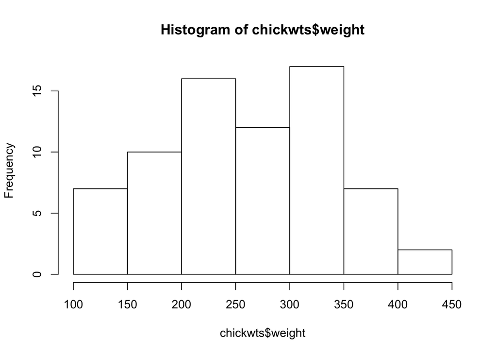

```r
hist(chickwts$weight)
```

That looks like something interesting might be going on. Lets try plotting this parsed by the type of feed. The `boxplot` has this built in using the `~` symbol to specify what we are parsing by.

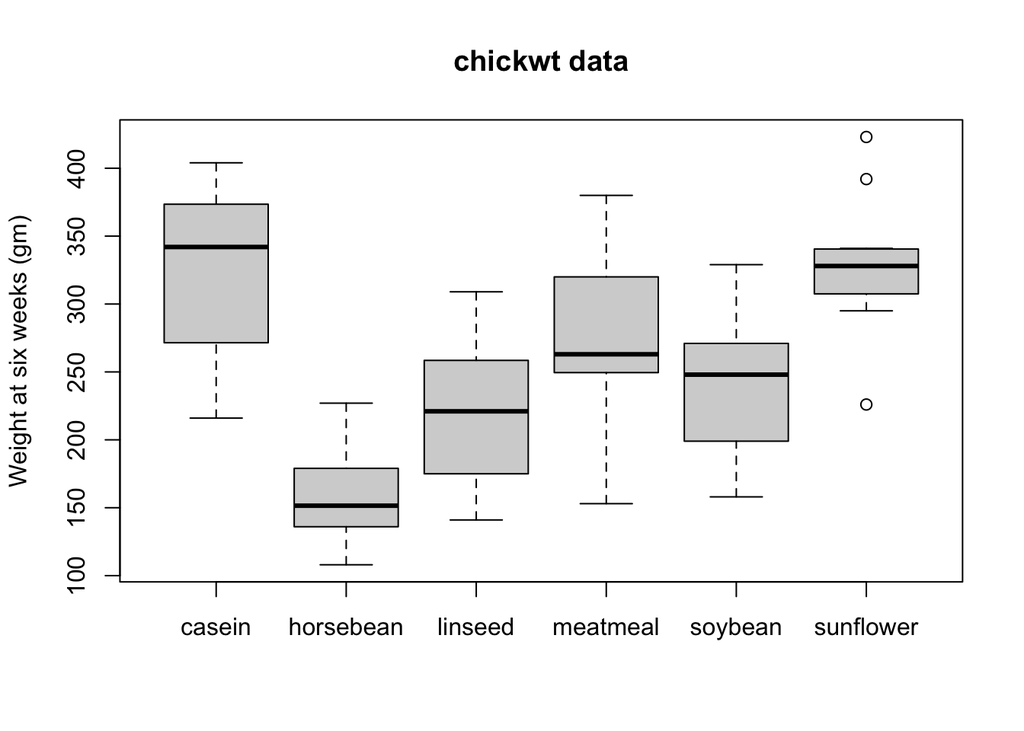

```r
boxplot(weight ~ feed, data = chickwts, col = "lightgray",
main = "chickwt data", ylab = "Weight at six weeks (gm)")
```

# Figures for manuscript

Now that we know what our data looks like lets produce figures for a manuscript. First we will use the `pdf` command this creates and opens the pdf file and that subsequent plotting commands are sent to. Once are plot is complete then we use the `dev.off` command to close the file:

this will be our figure 1 that is the distribution of all chick weights at 6 weeks:

```r
pdf(file="fig1.pdf", width = 4, height = 4)
hist(chickwts$weight, main = "Chick weights at 6 weeks",
xlab = "grams", ylab = "count")
dev.off()
```

next we will make our figure 2 that is the chick weights at 6 weeks parsed by feed type:

```r
pdf(file="fig2.pdf", width = 4, height = 4)
boxplot(weight ~ feed, data = chickwts, col = "lightgray",
main = "chickwt data", cex.axis=.5, ylab = "Weight at six weeks (gm)")
dev.off()
```